# Gustavo Diaz – texmeth25_discussion

- O’Brochta and Parikh. “Determining Politicians’ Electorally-Relevant Caste Membership”
- Atsusaka and Landsman. “When Does Ranked-Choice Voting Reduce Polarization?”

Sounds very different

Both about: **identity** matters for **electoral competition**

Sounds like studying *identity* is very important

## O’Brochta and Parikh

**Why you should care:**

- Tricky coding because candidates use/ignore caste depending on many contextual factors
- More complicated than your usual classification task

**Things I like:**

- Lots of domain knowledge in every step!
- Dealing with **electorally relevant** [caste] identity

## Questions

- Scaling up while preserving nuance?
- How many more to code this way to train a model?
- Why not just crowdsource everything? Or something word embedding style?
- How consequential is this for downstream inferential tasks?
- Standards for this kind of multi-layered coding?
- Campaigns = time in office?

## Atsusaka and Landsman

**Why you should care:**

- Unified modeling of voting behavior across electoral systems
- Very concrete ideas about implementing RCV

**Things I like:**

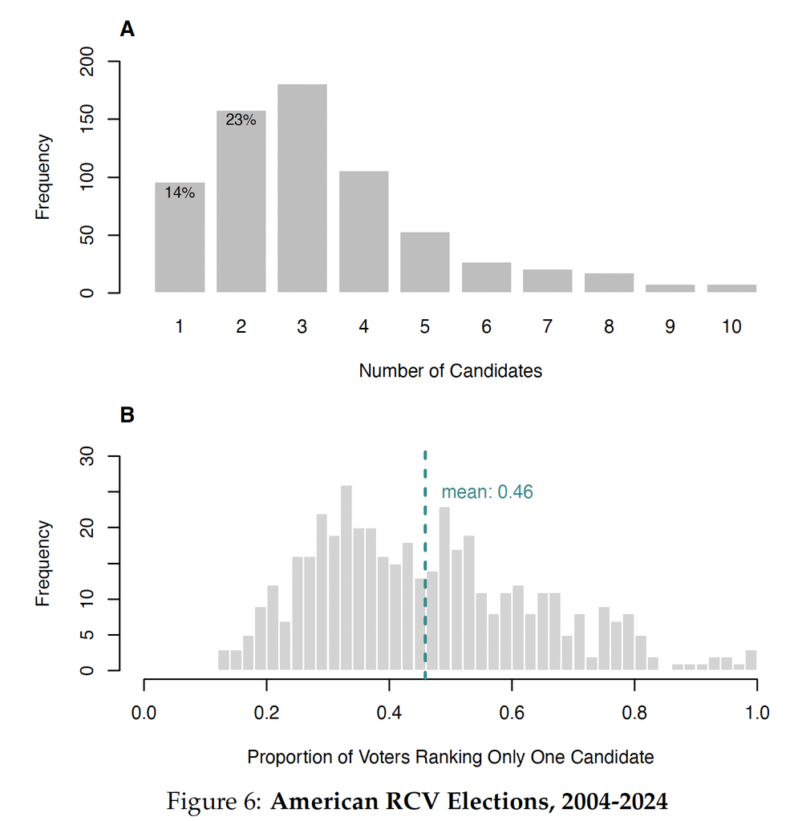

## Atsusaka and Landsman

**Why you should care:**

- Unified modeling of voting behavior across electoral systems
- Very concrete ideas about implementing RCV

**Things I like:**

- Modeling candidates and voters together
- Thinking of computational modeling as Bayesian inference

## Questions

- Why is this about *ethnic* polarization?
- Can we observe/estimate quantities of interest?
- Lab games?
- Model is static but simulation sequential?
- Four papers in one? Which comes first?